# outbreakteachR package tutorial overview

OJ Watson

2017-10-08

## Overview

The outbreakteachR R package has been designed to be an additional tool in helping assist with running the “paper outbreak” practical. The package assumes that the data has been collected and stored in a similar fashion to that presented within the xlsx file included within the external data directory. As such it will use the main data from the first sheet in the excel document, between columns A to O inclusive.

Given the above specifications, the tutorial below will give an overview of how to read in the data and produce a number of plots to help visualise the outbreak and present the key epidemiological parameters.

## Loading the data

First we will read in the data from wherever you have stored the .xlsx file. Below we will be using the example dataset included with the package.

```r
# First make sure the package is installed
devtools::install_github("mrc-ide/outbreakteachR", ref="mrc-branch")

# Load package - Warning messages will be thrown however these are not a problem
library(outbreakteachR)

# With the package installed first read in the data.
# This function will highlight rows where there may be errors in the excel file
# Remember to replace the argument for xlsx.file to the local file
# If it is on your desktop it will look something like:
# xlsx.file = "C:/Users/Bob/Desktop/savedworksheet.xlsx"
outbreak.dataset <- outbreakteachR::outbreak_dataset_read(
    xlsx.file = system.file("extdata","2016_solutions.xlsx",
                            package="outbreakteachR"),
    attempt.imputation = TRUE
    )

# Visualise the dataset
str(outbreak.dataset)
```

```
## 'data.frame':    144 obs. of  17 variables:
##  $ ID                                : num  1 2 3 4 4 4 5 6 7 8 ...
##  $ Parent.ID                         : num  NA NA NA 2 38 19 2 1 1 2 ...
##  $ Reinfection                       : logi  FALSE FALSE FALSE FALSE TRUE TRUE ...
##  $ Infection_Date                    : chr  "2016/10/17" "2016/10/17" "2016/10/17" "2016/10/17" ...
##  $ Infection_Time                    : chr  NA NA NA NA ...
##  $ Infection_Hours.since.start       : num  9.5 9.5 9.5 13.5 36.7 ...
##  $ Symptoms_Date                     : chr  NA NA NA NA ...
##  $ Symptoms_Time                     : chr  NA NA NA NA ...
##  $ Symptoms_Hours.since.start        : num  NA NA NA NA NA NA NA NA NA NA ...
##  $ End_Infection_Date                : chr  "2016/10/17" "2016/10/17" "2016/10/17" "2016/10/17" ...
##  $ End_Infection_Time                : chr  NA NA NA NA ...
##  $ End_Infection_Hours.since.start   : num  14 15 16.7 18.6 NA ...
##  $ Onward_Infection_Hours.since.start: num  13.9 13.5 16.7 17.6 NA ...
##  $ Latent_Period_Hours               : num  4.43 4 7.18 4.08 NA ...
##  $ Incubation_Period_Hours           : num  NA NA NA NA NA NA NA NA NA NA ...
##  $ Infectious_Period_Hours           : num  0.0667 1.5 0 1.0333 NA ...
##  $ Generation_Time_Hours             : num  NA NA NA 4 0.333 ...
```

## Create an infection network

For the next task we will need to subset the collected data so that we are only looking at those cases that were not reinfections. Using this subset of the data we will then be able to plot a number of static images from the network that will enable us to sere how the outbreak progressed in time.

```r
# Convert the read outbreak dataset into only the non-reinfections
first_infection_list <- outbreakteachR::first_infection_list(outbreak.dataset)

# The above function has now sorted our data into a list of two dataframes. These
# data frames show the "linelist" and "contacts" data. We can now see that the
# linelist data only possesses information about contacts that were not reinfections:

unique(first_infection_list$linelist$Reinfection)
```

```
## [1] FALSE
```

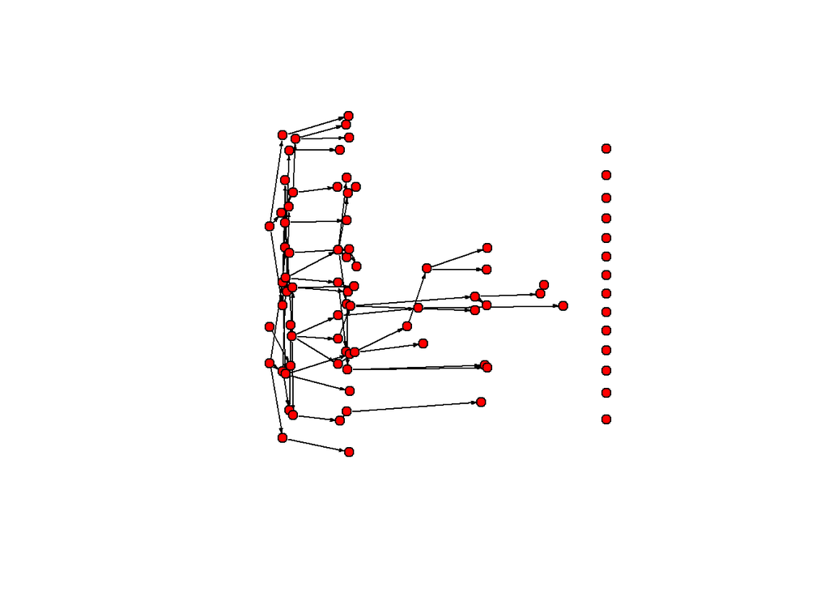

```r
# Next we will create a plot of the outbreak that is time-orientated, i.e. the relative
# node positions represents the point in time that an individual was infected:

outbreakteachR::infection_network_plot(first_infection_list = first_infection_list,
                                       time = TRUE, log = FALSE)
```

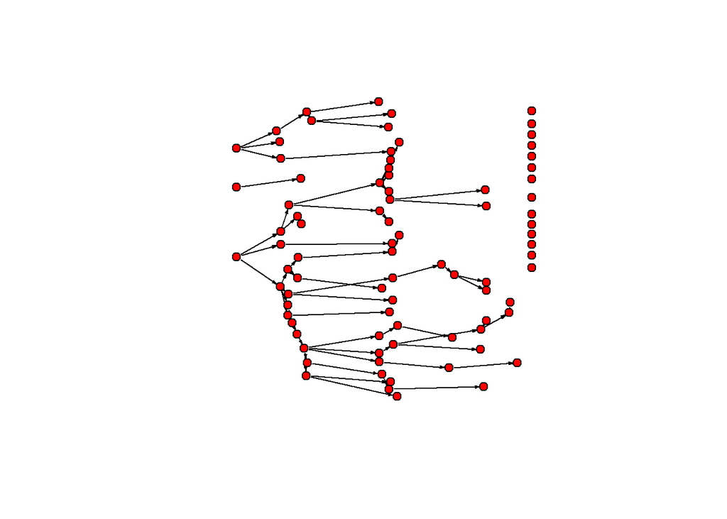

```r
# We might find that the outbreak is quite cramped in teh above as a lot of infections happen over
# a very short time frame with respect to the 5 day outbreak. We can thus log transform the times of
# infection to spread out the outbreak for further clarity at the earlier stages

outbreakteachR::infection_network_plot(first_infection_list = first_infection_list,
                                       time = TRUE, log = TRUE)
```

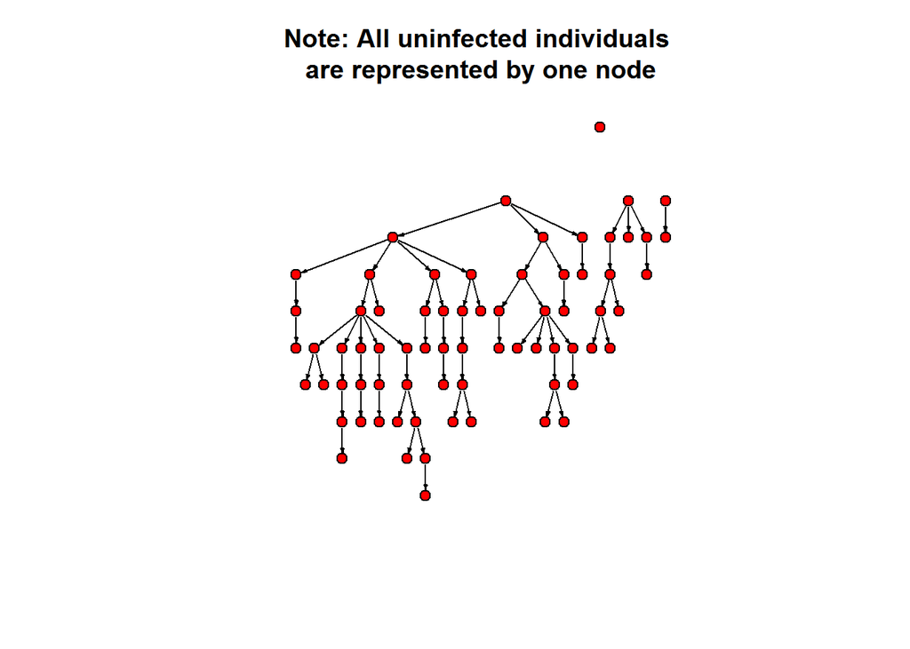

```r
# We can also visualise the network in a more "tree" like fashion which shows each
# infection event with an equal length branch for easier visualisation:

outbreakteachR::infection_network_plot(first_infection_list = first_infection_list,
                                       time = FALSE)
```

```
## Edge activity in base.net was ignored
## Created net.obs.period to describe network
##  Network observation period info:
##   Number of observation spells: 1
##   Maximal time range observed: -Inf until Inf
##   Temporal mode: continuous
##   Time unit: unknown
##   Suggested time increment: NA
```

```
## No coordinate information found in network, running compute.animation
```

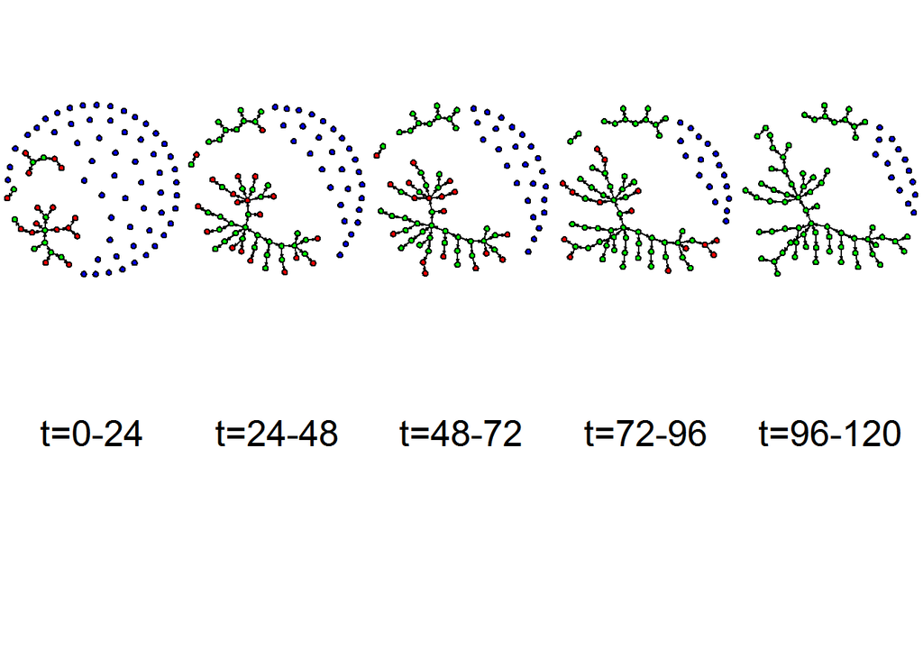

```r
# Lastly we can visualise what the outbreak looked like by viewing the outbreak
# at the end of each day, i.e. at 24 hour intervals

outbreakteachR::daily_timeseries_plot(first_infection_list=first_infection_list)
```

## Animate the infection network

So far we have only been able to visualise the outbreak at discrete moments in time. To improve this we can also create an html page showing an animation of the outbreak process. (This will take a minute or two).

```r
# Change the file parameter to wherever you want the html to be stored
  outbreakteachR::animate_infection_network(first_infection_list=first_infection_list,
                            file=paste(getwd(),"/Animated-Network-Dynamic.html",sep=""),
                            year=2016,
                            detach=FALSE)
```

```
## Edge activity in base.net was ignored
## Created net.obs.period to describe network
##  Network observation period info:
##   Number of observation spells: 1
##   Maximal time range observed: -Inf until Inf
##   Temporal mode: continuous
##   Time unit: unknown
##   Suggested time increment: NA
```

[interactive chart not shown]

## Epidemic Time Series

We can also use the collected data to plot the epidemic time series, using the times recorded for when the infection started and ended in each individual.

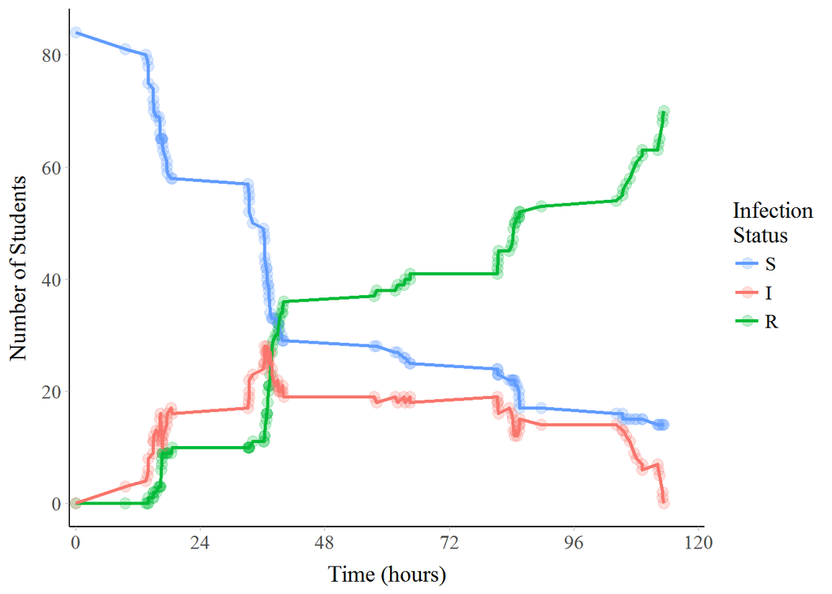

```r
outbreakteachR::epidemic_timeseries_plot(outbreak.dataset = outbreak.dataset)
```

## Parameter investigation

We can also examine the distribution of the epidemiological parameters.

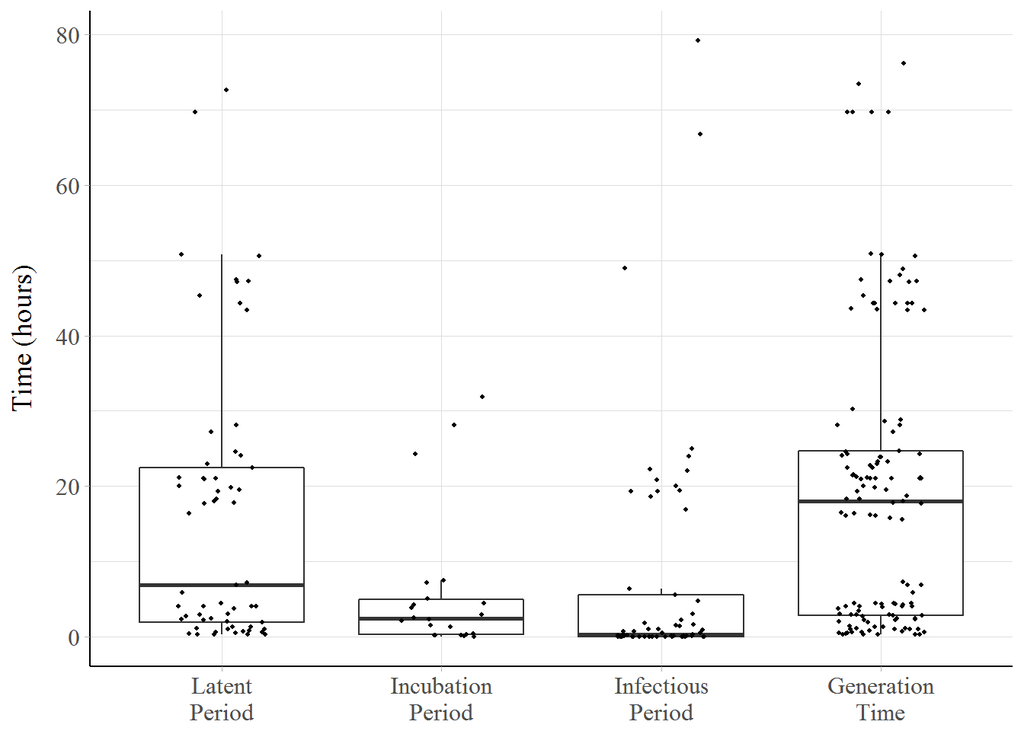

```r
outbreakteachR::paramater_boxplots_plot(outbreak.dataset=outbreak.dataset)
```

We might also want to view the offspring distribution to see how it compares to the Poisson distribution that was used to generate the actual observed data.

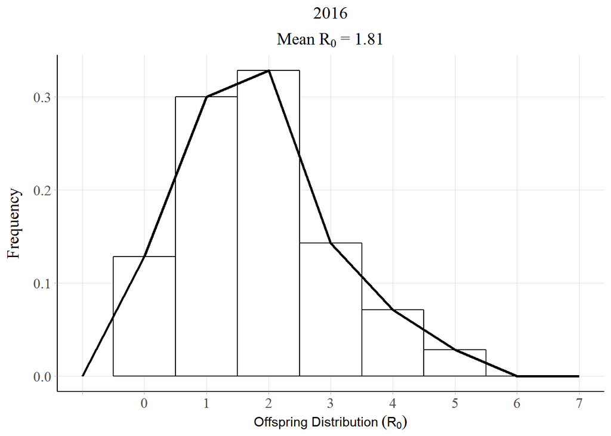

```r
outbreakteachR::offspring_distribution_plot(outbreak.dataset=outbreak.dataset,
                                            include.reinfectons = TRUE,
                                            title = 2016)
```

What we can see from above is the confirmed number of secondary cases from each individual, which has a mean very close to 1.8. However if we might also want to look at the distribution describing only the successful contacts, i.e. those that led to infections rather than reinfections.

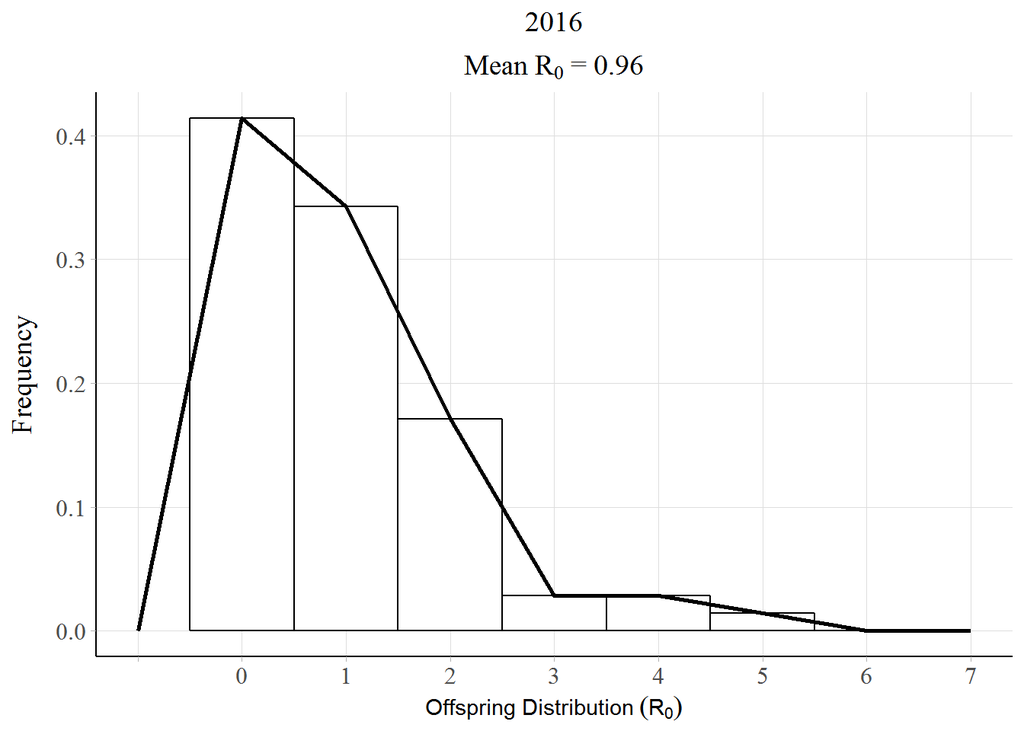

```r
outbreakteachR::offspring_distribution_plot(outbreak.dataset=outbreak.dataset,
                                            include.reinfectons = FALSE,
                                            title=2016)
```

## Simulated outbreaks

It can often be very useful to see how this outbreak may compare to a simulated outbreak. To do this we can use the following function to simulate 200 outbreaks and plot the interquartile range of these simulations:

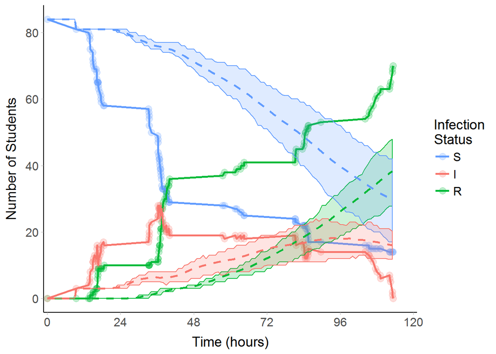

```r
outbreakteachR::bootstrap_simulated_plot(
  first_infection_list = first_infection_list,
  outbreak.dataset = outbreak.dataset,
  lower.quantile=0.25,
  upper.quantile=0.75,
  include.observed = T,
  replicates = 200)
```

To give some more information into how the simulated outbreaks are modeled. For these simulations we assume each simulation is seeded with three infections at the same time as the observed outbreak, and has a total population size equal to the outbreak dataset. The number of secondary infections is then drawn from a Poisson distribution with a mean of 1.8, as was used in the practical. The time of each infection is also drawn from a Poisson with a mean equal to the observed mean generation times. The infected individual then recovers after a period of time, which is sampled from a Poisson with mean equal to the mean infectious period. If they do not infect anyone then they recover after a period of time drawn from a Poisson with mean equal to the mean recovery time for the observed outbreak. Simulations are then stopped after a period of time equal to the length of the observed outbreak.

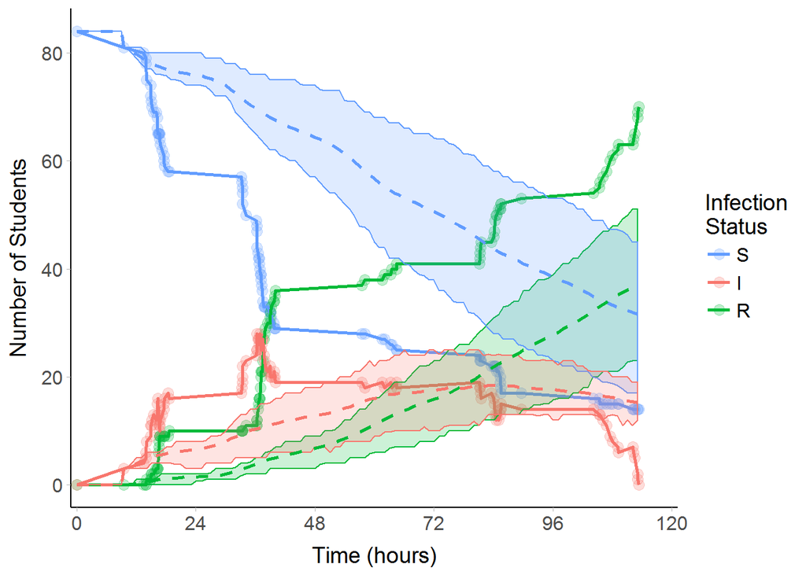

```r
outbreakteachR::bootstrap_simulated_plot(
  first_infection_list = first_infection_list,
  outbreak.dataset = outbreak.dataset,
  lower.quantile = 0.25,
  upper.quantile = 0.75,
  include.observed = T,
  replicates = 200,
  sampling = TRUE)
```

## Summary and further thoughts

Hopefully the above tutorial has shown how the *outbreakteachR* outbreak practical can be extended using R to extend the analysis and aid in visualising the outbreak process.